# GLM

Belhalfaoui Aziz

2024-06-30

# —————————————-

# Projet 30 Juin - modele lineaire GLM

# —————————————-

```r
library(tidyverse)
#import de la base de données
meteo <- read.csv("C:/Users/BelhaA/OneDrive - Louis Dreyfus Company/Desktop/Master Statistiques et Big Data - 2024/Rproject/Modele Lineraire Generalisé - Robin/meteo.train.csv")
str(meteo)
```

```
## 'data.frame':    1180 obs. of  47 variables:
##  $ X                                           : int  2 4 6 8 10 12 14 16 18 20 ...
##  $ Year                                        : int  2010 2010 2010 2010 2010 2010 2010 2010 2010 2010 ...
##  $ Month                                       : int  6 6 6 6 6 6 6 6 6 6 ...
##  $ Day                                         : int  2 4 6 8 10 12 14 16 18 20 ...
##  $ Hour                                        : int  0 0 0 0 0 0 0 0 0 0 ...
##  $ Minute                                      : int  0 0 0 0 0 0 0 0 0 0 ...
##  $ Temperature.daily.mean..2.m.above.gnd.      : num  15 17.3 21.6 20.2 22.6 ...
##  $ Relative.Humidity.daily.mean..2.m.above.gnd.: num  76.5 77.6 69.5 75.1 73.5 ...
##  $ Mean.Sea.Level.Pressure.daily.mean..MSL.    : num  1015 1017 1015 1008 1004 ...
##  $ Total.Precipitation.daily.sum..sfc.         : num  1 0 3.7 0.2 0 2.2 1.8 1.8 17.5 1.2 ...
##  $ Snowfall.amount.raw.daily.sum..sfc.         : num  0 0 0 0 0 0 0 0 0 0 ...
##  $ Total.Cloud.Cover.daily.mean..sfc.          : num  79.8 4.7 42.1 67.5 56.3 ...
##  $ High.Cloud.Cover.daily.mean..high.cld.lay.  : num  3 0.67 21.21 54.71 50.25 ...
##  $ Medium.Cloud.Cover.daily.mean..mid.cld.lay. : num  31.6 0 25.9 65.8 55.3 ...
```

[output cut: 33 more lines]

# —————————————-

# Exploration et cleaning des données

# —————————————-

Exploration de la base de données (donneés manquantes)

```r
#find missing rows
find_missing_rows <- function(data) {
  missing_rows <- data %>%
    mutate(row_number = row_number()) %>%
    filter(if_any(everything(), is.na)) %>%
    pull(row_number)

  if (length(missing_rows) == 0) {
    message("Pas de données manquantes")
  } else {
    message("Lignes avec des valeurs manquantes : ", paste(missing_rows, collapse = ", "))
  }
}

find_missing_rows(meteo)
```

```
## Pas de données manquantes
```

On voit qu’un certain nombre de variables sont tres correlées entre elles. Il est donc important de cleaner la base de donnée

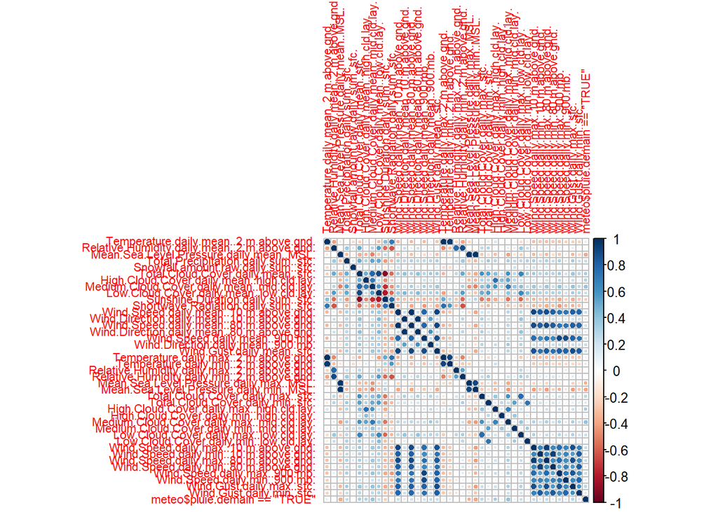

```r
#etude de correlation
library(corrplot)
corr_matrix = cor(cbind(meteo[, 7:46], meteo$pluie.demain == "TRUE"))
corrplot(corr_matrix, tl.cex = 0.7)
```

On supprime toutes les variables qui ont plus de 80% de correlation Notre nouvelle base de donnée ne comporte plus que 27 variables

```r
# cleaning de la bdd
library(caret)
highly_correlated <- findCorrelation(corr_matrix, cutoff = 0.8)
toremove = colnames(corr_matrix)[highly_correlated]

meteo_clean =  meteo %>%
  select(-one_of(toremove), -c(1,5,6))

str(meteo_clean)
```

```
## 'data.frame':    1180 obs. of  27 variables:
##  $ Year                                        : int  2010 2010 2010 2010 2010 2010 2010 2010 2010 2010 ...
##  $ Month                                       : int  6 6 6 6 6 6 6 6 6 6 ...
##  $ Day                                         : int  2 4 6 8 10 12 14 16 18 20 ...
##  $ Temperature.daily.mean..2.m.above.gnd.      : num  15 17.3 21.6 20.2 22.6 ...
##  $ Relative.Humidity.daily.mean..2.m.above.gnd.: num  76.5 77.6 69.5 75.1 73.5 ...
##  $ Mean.Sea.Level.Pressure.daily.mean..MSL.    : num  1015 1017 1015 1008 1004 ...
##  $ Total.Precipitation.daily.sum..sfc.         : num  1 0 3.7 0.2 0 2.2 1.8 1.8 17.5 1.2 ...
##  $ Snowfall.amount.raw.daily.sum..sfc.         : num  0 0 0 0 0 0 0 0 0 0 ...
##  $ High.Cloud.Cover.daily.mean..high.cld.lay.  : num  3 0.67 21.21 54.71 50.25 ...
##  $ Medium.Cloud.Cover.daily.mean..mid.cld.lay. : num  31.6 0 25.9 65.8 55.3 ...
##  $ Low.Cloud.Cover.daily.mean..low.cld.lay.    : num  79.2 4.5 35.3 18.9 34.2 ...
##  $ Shortwave.Radiation.daily.sum..sfc.         : num  6710 7974 4834 5390 7216 ...
##  $ Wind.Direction.daily.mean..80.m.above.gnd.  : num  268 199 208 206 186 ...
##  $ Wind.Direction.daily.mean..900.mb.          : num  180.4 93.7 250.1 238.6 153 ...
##  $ Relative.Humidity.daily.max..2.m.above.gnd. : int  94 92 91 89 97 92 96 96 97 95 ...
##  $ Total.Cloud.Cover.daily.max..sfc.           : num  100 28 100 100 100 100 100 100 100 100 ...
##  $ Total.Cloud.Cover.daily.min..sfc.           : num  0 0 0 0 0 0 0 100 0 0 ...
##  $ High.Cloud.Cover.daily.max..high.cld.lay.   : int  16 11 100 100 100 28 100 100 100 24 ...
##  $ High.Cloud.Cover.daily.min..high.cld.lay.   : int  0 0 0 0 0 0 0 0 0 0 ...
##  $ Medium.Cloud.Cover.daily.max..mid.cld.lay.  : int  100 0 100 100 100 100 100 100 100 41 ...
##  $ Medium.Cloud.Cover.daily.min..mid.cld.lay.  : int  0 0 0 0 0 0 0 0 0 0 ...
##  $ Low.Cloud.Cover.daily.max..low.cld.lay.     : int  100 28 100 100 100 100 100 100 100 100 ...
##  $ Low.Cloud.Cover.daily.min..low.cld.lay.     : int  0 0 0 0 0 0 0 29 0 0 ...
##  $ Wind.Speed.daily.max..80.m.above.gnd.       : num  23.8 18.7 32 10.2 23.4 ...
##  $ Wind.Speed.daily.min..80.m.above.gnd.       : num  8.65 0 0.51 1.44 2.97 ...
##  $ Wind.Speed.daily.min..900.mb.               : num  12.25 6.62 5.48 4.69 4.68 ...
##  $ pluie.demain                                : logi  FALSE FALSE TRUE TRUE TRUE TRUE ...
```

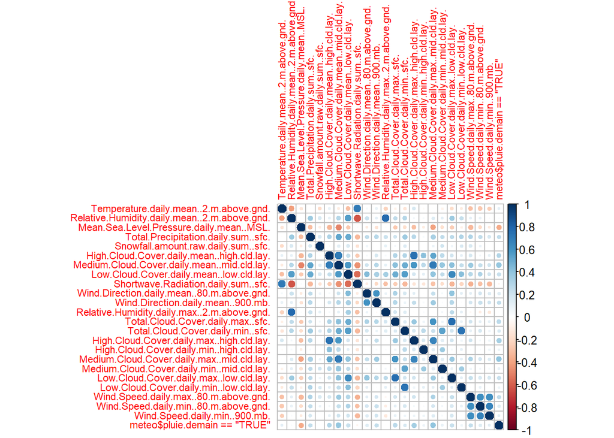

```r
#test du corrplot sur les nouvelles données
corrplot(cor(cbind(meteo_clean[, 4:26], meteo$pluie.demain == "TRUE")), tl.cex = 0.7)
```

# —————————————-

# Lancement et test du modele

# —————————————-

Test du modele saturé

```r
g1 = glm(pluie.demain ~ ., data = meteo_clean, family = binomial)
summary(g1)
```

```
##
## Call:
## glm(formula = pluie.demain ~ ., family = binomial, data = meteo_clean)
##
## Deviance Residuals:
##     Min       1Q   Median       3Q      Max
## -2.4991  -0.8989   0.3900   0.8491   2.8449
##
## Coefficients:
##                                                Estimate Std. Error z value
## (Intercept)                                  -6.287e+01  6.293e+01  -0.999
## Year                                          5.833e-02  3.103e-02   1.880
## Month                                        -1.908e-02  2.383e-02  -0.801
## Day                                           8.321e-03  7.875e-03   1.057
## Temperature.daily.mean..2.m.above.gnd.        3.336e-02  1.880e-02   1.774
## Relative.Humidity.daily.mean..2.m.above.gnd. -4.281e-03  1.668e-02  -0.257
## Mean.Sea.Level.Pressure.daily.mean..MSL.     -5.825e-02  1.131e-02  -5.150
## Total.Precipitation.daily.sum..sfc.           1.483e-02  2.489e-02   0.596
## Snowfall.amount.raw.daily.sum..sfc.          -2.671e-01  1.896e-01  -1.409
## High.Cloud.Cover.daily.mean..high.cld.lay.   -1.575e-03  6.427e-03  -0.245
## Medium.Cloud.Cover.daily.mean..mid.cld.lay.   6.301e-03  5.334e-03   1.181
## Low.Cloud.Cover.daily.mean..low.cld.lay.      3.273e-03  4.410e-03   0.742
## Shortwave.Radiation.daily.sum..sfc.           1.205e-04  7.531e-05   1.600
## Wind.Direction.daily.mean..80.m.above.gnd.   -3.766e-03  1.587e-03  -2.373
## Wind.Direction.daily.mean..900.mb.            4.945e-03  1.316e-03   3.757
## Relative.Humidity.daily.max..2.m.above.gnd.   1.576e-02  1.623e-02   0.971
## Total.Cloud.Cover.daily.max..sfc.             3.258e-03  4.598e-03   0.708
## Total.Cloud.Cover.daily.min..sfc.             7.476e-03  6.105e-03   1.224
## High.Cloud.Cover.daily.max..high.cld.lay.     3.758e-03  2.795e-03   1.344
## High.Cloud.Cover.daily.min..high.cld.lay.     7.063e-03  1.970e-02   0.359
## Medium.Cloud.Cover.daily.max..mid.cld.lay.    7.289e-03  3.053e-03   2.388
## Medium.Cloud.Cover.daily.min..mid.cld.lay.   -4.197e-03  8.841e-03  -0.475
## Low.Cloud.Cover.daily.max..low.cld.lay.       3.074e-03  3.241e-03   0.948
## Low.Cloud.Cover.daily.min..low.cld.lay.       6.877e-04  6.860e-03   0.100
## Wind.Speed.daily.max..80.m.above.gnd.         3.114e-02  9.808e-03   3.175
## Wind.Speed.daily.min..80.m.above.gnd.        -1.458e-02  1.887e-02  -0.772
## Wind.Speed.daily.min..900.mb.                 4.577e-03  9.131e-03   0.501
##                                              Pr(>|z|)
## (Intercept)                                  0.317785
## Year                                         0.060136 .
```

[output cut: 20 more lines]

```
## Low.Cloud.Cover.daily.max..low.cld.lay.      0.342896
## Low.Cloud.Cover.daily.min..low.cld.lay.      0.920159
## Wind.Speed.daily.max..80.m.above.gnd.        0.001500 **
## Wind.Speed.daily.min..80.m.above.gnd.        0.439837
## Wind.Speed.daily.min..900.mb.                0.616174
## ---
## Signif. codes:  0 '***' 0.001 '**' 0.01 '*' 0.05 '.' 0.1 ' ' 1
##
## (Dispersion parameter for binomial family taken to be 1)
##
##     Null deviance: 1635.4  on 1179  degrees of freedom
## Residual deviance: 1282.7  on 1153  degrees of freedom
## AIC: 1336.7
##
## Number of Fisher Scoring iterations: 4
```

Perfectionnement du modele par la selection automatique de variables selon le critere AIC La deviance de notre modele Mk semble plus elevée que celle du modele saturé (bien que de peu) Le modele a une deviance residuelle superieure au nombre de degrés de liberté, il ne capte pas bien toute la variabilité des données

```r
g2 = step(g1)
```

```
## Start:  AIC=1336.67
## pluie.demain ~ Year + Month + Day + Temperature.daily.mean..2.m.above.gnd. +
##     Relative.Humidity.daily.mean..2.m.above.gnd. + Mean.Sea.Level.Pressure.daily.mean..MSL. +
##     Total.Precipitation.daily.sum..sfc. + Snowfall.amount.raw.daily.sum..sfc. +
##     High.Cloud.Cover.daily.mean..high.cld.lay. + Medium.Cloud.Cover.daily.mean..mid.cld.lay. +
##     Low.Cloud.Cover.daily.mean..low.cld.lay. + Shortwave.Radiation.daily.sum..sfc. +
##     Wind.Direction.daily.mean..80.m.above.gnd. + Wind.Direction.daily.mean..900.mb. +
##     Relative.Humidity.daily.max..2.m.above.gnd. + Total.Cloud.Cover.daily.max..sfc. +
##     Total.Cloud.Cover.daily.min..sfc. + High.Cloud.Cover.daily.max..high.cld.lay. +
##     High.Cloud.Cover.daily.min..high.cld.lay. + Medium.Cloud.Cover.daily.max..mid.cld.lay. +
##     Medium.Cloud.Cover.daily.min..mid.cld.lay. + Low.Cloud.Cover.daily.max..low.cld.lay. +
##     Low.Cloud.Cover.daily.min..low.cld.lay. + Wind.Speed.daily.max..80.m.above.gnd. +
##     Wind.Speed.daily.min..80.m.above.gnd. + Wind.Speed.daily.min..900.mb.
##
##                                                Df Deviance    AIC
## - Low.Cloud.Cover.daily.min..low.cld.lay.       1   1282.7 1334.7
## - High.Cloud.Cover.daily.mean..high.cld.lay.    1   1282.7 1334.7
## - Relative.Humidity.daily.mean..2.m.above.gnd.  1   1282.7 1334.7
## - High.Cloud.Cover.daily.min..high.cld.lay.     1   1282.8 1334.8
## - Medium.Cloud.Cover.daily.min..mid.cld.lay.    1   1282.9 1334.9
## - Wind.Speed.daily.min..900.mb.                 1   1282.9 1334.9
## - Total.Precipitation.daily.sum..sfc.           1   1283.0 1335.0
## - Total.Cloud.Cover.daily.max..sfc.             1   1283.2 1335.2
## - Low.Cloud.Cover.daily.mean..low.cld.lay.      1   1283.2 1335.2
## - Wind.Speed.daily.min..80.m.above.gnd.         1   1283.3 1335.3
## - Month                                         1   1283.3 1335.3
## - Low.Cloud.Cover.daily.max..low.cld.lay.       1   1283.6 1335.6
## - Relative.Humidity.daily.max..2.m.above.gnd.   1   1283.6 1335.6
## - Day                                           1   1283.8 1335.8
## - Medium.Cloud.Cover.daily.mean..mid.cld.lay.   1   1284.1 1336.1
## - Total.Cloud.Cover.daily.min..sfc.             1   1284.2 1336.2
## - High.Cloud.Cover.daily.max..high.cld.lay.     1   1284.5 1336.5
## <none>                                              1282.7 1336.7
## - Snowfall.amount.raw.daily.sum..sfc.           1   1284.7 1336.7
## - Shortwave.Radiation.daily.sum..sfc.           1   1285.2 1337.2
## - Temperature.daily.mean..2.m.above.gnd.        1   1285.8 1337.8
## - Year                                          1   1286.2 1338.2
## - Wind.Direction.daily.mean..80.m.above.gnd.    1   1288.4 1340.4
## - Medium.Cloud.Cover.daily.max..mid.cld.lay.    1   1288.4 1340.4
## - Wind.Speed.daily.max..80.m.above.gnd.         1   1293.0 1345.0
```

[output cut: 390 more lines]

```
## <none>                                             1287.3 1317.3
## - Medium.Cloud.Cover.daily.mean..mid.cld.lay.  1   1289.7 1317.7
## - Relative.Humidity.daily.max..2.m.above.gnd.  1   1289.7 1317.7
## - High.Cloud.Cover.daily.max..high.cld.lay.    1   1289.8 1317.8
## - Snowfall.amount.raw.daily.sum..sfc.          1   1289.8 1317.8
## - Temperature.daily.mean..2.m.above.gnd.       1   1290.7 1318.7
## - Year                                         1   1292.1 1320.1
## - Shortwave.Radiation.daily.sum..sfc.          1   1292.4 1320.4
## - Wind.Direction.daily.mean..80.m.above.gnd.   1   1292.7 1320.7
## - Total.Cloud.Cover.daily.min..sfc.            1   1292.9 1320.9
## - Low.Cloud.Cover.daily.max..low.cld.lay.      1   1292.9 1320.9
## - Medium.Cloud.Cover.daily.max..mid.cld.lay.   1   1298.0 1326.0
## - Wind.Direction.daily.mean..900.mb.           1   1302.5 1330.5
## - Wind.Speed.daily.max..80.m.above.gnd.        1   1302.9 1330.9
## - Mean.Sea.Level.Pressure.daily.mean..MSL.     1   1316.6 1344.6
```

```r
summary(g2)
```

```
##
## Call:
## glm(formula = pluie.demain ~ Year + Temperature.daily.mean..2.m.above.gnd. +
##     Mean.Sea.Level.Pressure.daily.mean..MSL. + Snowfall.amount.raw.daily.sum..sfc. +
##     Medium.Cloud.Cover.daily.mean..mid.cld.lay. + Shortwave.Radiation.daily.sum..sfc. +
##     Wind.Direction.daily.mean..80.m.above.gnd. + Wind.Direction.daily.mean..900.mb. +
##     Relative.Humidity.daily.max..2.m.above.gnd. + Total.Cloud.Cover.daily.min..sfc. +
##     High.Cloud.Cover.daily.max..high.cld.lay. + Medium.Cloud.Cover.daily.max..mid.cld.lay. +
##     Low.Cloud.Cover.daily.max..low.cld.lay. + Wind.Speed.daily.max..80.m.above.gnd.,
##     family = binomial, data = meteo_clean)
##
## Deviance Residuals:
##     Min       1Q   Median       3Q      Max
## -2.4158  -0.8972   0.3786   0.8522   2.7725
##
## Coefficients:
##                                               Estimate Std. Error z value
## (Intercept)                                 -7.652e+01  6.102e+01  -1.254
## Year                                         6.531e-02  2.995e-02   2.180
## Temperature.daily.mean..2.m.above.gnd.       2.976e-02  1.619e-02   1.838
## Mean.Sea.Level.Pressure.daily.mean..MSL.    -5.882e-02  1.113e-02  -5.287
## Snowfall.amount.raw.daily.sum..sfc.         -2.765e-01  1.777e-01  -1.556
## Medium.Cloud.Cover.daily.mean..mid.cld.lay.  6.469e-03  4.226e-03   1.531
## Shortwave.Radiation.daily.sum..sfc.          1.288e-04  5.713e-05   2.254
## Wind.Direction.daily.mean..80.m.above.gnd.  -3.477e-03  1.508e-03  -2.306
## Wind.Direction.daily.mean..900.mb.           4.999e-03  1.296e-03   3.857
## Relative.Humidity.daily.max..2.m.above.gnd.  1.556e-02  1.009e-02   1.541
## Total.Cloud.Cover.daily.min..sfc.            8.761e-03  3.785e-03   2.315
## High.Cloud.Cover.daily.max..high.cld.lay.    3.431e-03  2.165e-03   1.584
## Medium.Cloud.Cover.daily.max..mid.cld.lay.   8.336e-03  2.567e-03   3.248
## Low.Cloud.Cover.daily.max..low.cld.lay.      5.341e-03  2.264e-03   2.359
## Wind.Speed.daily.max..80.m.above.gnd.        3.038e-02  7.875e-03   3.857
##                                             Pr(>|z|)
## (Intercept)                                 0.209842
## Year                                        0.029221 *
## Temperature.daily.mean..2.m.above.gnd.      0.066084 .
## Mean.Sea.Level.Pressure.daily.mean..MSL.    1.25e-07 ***
## Snowfall.amount.raw.daily.sum..sfc.         0.119750
## Medium.Cloud.Cover.daily.mean..mid.cld.lay. 0.125834
## Shortwave.Radiation.daily.sum..sfc.         0.024190 *
## Wind.Direction.daily.mean..80.m.above.gnd.  0.021107 *
## Wind.Direction.daily.mean..900.mb.          0.000115 ***
## Relative.Humidity.daily.max..2.m.above.gnd. 0.123223
## Total.Cloud.Cover.daily.min..sfc.           0.020618 *
## High.Cloud.Cover.daily.max..high.cld.lay.   0.113092
## Medium.Cloud.Cover.daily.max..mid.cld.lay.  0.001163 **
## Low.Cloud.Cover.daily.max..low.cld.lay.     0.018333 *
## Wind.Speed.daily.max..80.m.above.gnd.       0.000115 ***
## ---
## Signif. codes:  0 '***' 0.001 '**' 0.01 '*' 0.05 '.' 0.1 ' ' 1
##
## (Dispersion parameter for binomial family taken to be 1)
##
##     Null deviance: 1635.4  on 1179  degrees of freedom
## Residual deviance: 1287.3  on 1165  degrees of freedom
## AIC: 1317.3
##
## Number of Fisher Scoring iterations: 4
```

Preference pour le modele g2, peu de difference de deviance et une simplification du modele

```r
#anova
anova(g1, g2, test = "LRT")
```

```
## Analysis of Deviance Table
##
## Model 1: pluie.demain ~ Year + Month + Day + Temperature.daily.mean..2.m.above.gnd. +
##     Relative.Humidity.daily.mean..2.m.above.gnd. + Mean.Sea.Level.Pressure.daily.mean..MSL. +
##     Total.Precipitation.daily.sum..sfc. + Snowfall.amount.raw.daily.sum..sfc. +
##     High.Cloud.Cover.daily.mean..high.cld.lay. + Medium.Cloud.Cover.daily.mean..mid.cld.lay. +
##     Low.Cloud.Cover.daily.mean..low.cld.lay. + Shortwave.Radiation.daily.sum..sfc. +
##     Wind.Direction.daily.mean..80.m.above.gnd. + Wind.Direction.daily.mean..900.mb. +
##     Relative.Humidity.daily.max..2.m.above.gnd. + Total.Cloud.Cover.daily.max..sfc. +
##     Total.Cloud.Cover.daily.min..sfc. + High.Cloud.Cover.daily.max..high.cld.lay. +
##     High.Cloud.Cover.daily.min..high.cld.lay. + Medium.Cloud.Cover.daily.max..mid.cld.lay. +
##     Medium.Cloud.Cover.daily.min..mid.cld.lay. + Low.Cloud.Cover.daily.max..low.cld.lay. +
##     Low.Cloud.Cover.daily.min..low.cld.lay. + Wind.Speed.daily.max..80.m.above.gnd. +
##     Wind.Speed.daily.min..80.m.above.gnd. + Wind.Speed.daily.min..900.mb.
## Model 2: pluie.demain ~ Year + Temperature.daily.mean..2.m.above.gnd. +
##     Mean.Sea.Level.Pressure.daily.mean..MSL. + Snowfall.amount.raw.daily.sum..sfc. +
##     Medium.Cloud.Cover.daily.mean..mid.cld.lay. + Shortwave.Radiation.daily.sum..sfc. +
##     Wind.Direction.daily.mean..80.m.above.gnd. + Wind.Direction.daily.mean..900.mb. +
##     Relative.Humidity.daily.max..2.m.above.gnd. + Total.Cloud.Cover.daily.min..sfc. +
##     High.Cloud.Cover.daily.max..high.cld.lay. + Medium.Cloud.Cover.daily.max..mid.cld.lay. +
##     Low.Cloud.Cover.daily.max..low.cld.lay. + Wind.Speed.daily.max..80.m.above.gnd.
##   Resid. Df Resid. Dev  Df Deviance Pr(>Chi)
## 1      1153     1282.7
## 2      1165     1287.3 -12  -4.6433   0.9688
```

Affichage des résidus et valeurs aberrantes

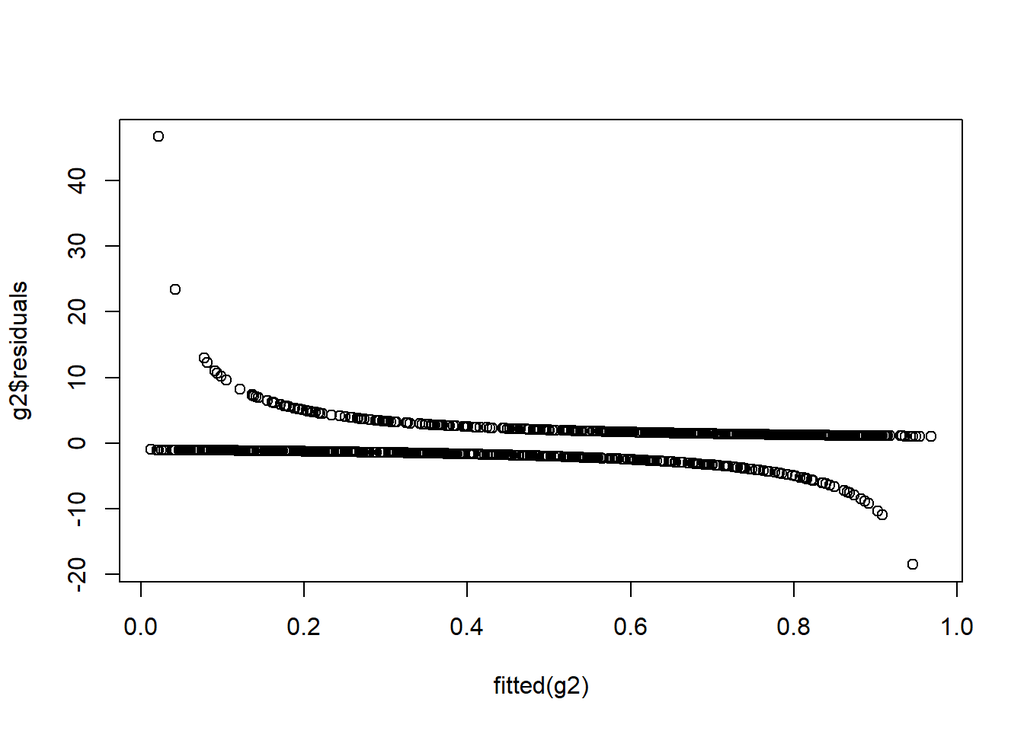

```r
#affichage des résidus et identification des valeurs aberrantes
plot(fitted(g2),g2$residuals)
```

Il semble qu’il y ai une valeur aberrante en ligne 363 (que nous decidons de garder)

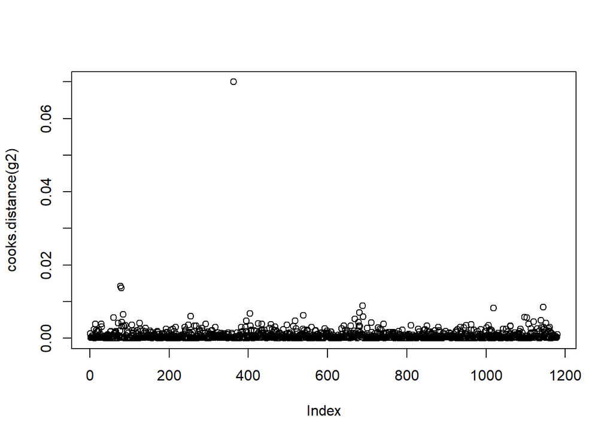

```r
plot(cooks.distance(g2))
```

Pas de problème de multicollinéarité significatif

```r
#test de multicolinearité
library(car)
vif(g2)
```

```
##                                        Year
##                                    1.078025
##      Temperature.daily.mean..2.m.above.gnd.
##                                    2.666974
##    Mean.Sea.Level.Pressure.daily.mean..MSL.
##                                    1.287616
##         Snowfall.amount.raw.daily.sum..sfc.
##                                    1.117787
## Medium.Cloud.Cover.daily.mean..mid.cld.lay.
##                                    3.026377
##         Shortwave.Radiation.daily.sum..sfc.
##                                    3.366467
##  Wind.Direction.daily.mean..80.m.above.gnd.
##                                    1.920998
##          Wind.Direction.daily.mean..900.mb.
##                                    1.917187
## Relative.Humidity.daily.max..2.m.above.gnd.
##                                    1.273735
##           Total.Cloud.Cover.daily.min..sfc.
##                                    1.409425
##   High.Cloud.Cover.daily.max..high.cld.lay.
##                                    1.819162
##  Medium.Cloud.Cover.daily.max..mid.cld.lay.
##                                    2.261842
##     Low.Cloud.Cover.daily.max..low.cld.lay.
##                                    1.520528
##       Wind.Speed.daily.max..80.m.above.gnd.
##                                    1.348565
```

# —————————————-

# —————————————-

Separation en données de test et entrainement

```r
#validation croisée
train_indices = sample(c(T, F), nrow(meteo_clean), replace = T, prob = c(.8, .2))
meteo_train = meteo_clean[train_indices,]
meteo_test = meteo_clean[!train_indices,]
```

```r
g3 =  glm(pluie.demain ~
              Year+
              Temperature.daily.mean..2.m.above.gnd.+
              Mean.Sea.Level.Pressure.daily.mean..MSL.+
              Snowfall.amount.raw.daily.sum..sfc.+
              Medium.Cloud.Cover.daily.mean..mid.cld.lay.+
              Shortwave.Radiation.daily.sum..sfc.+
              Wind.Direction.daily.mean..80.m.above.gnd.+
              Wind.Direction.daily.mean..900.mb.+
              Relative.Humidity.daily.max..2.m.above.gnd.+
              Total.Cloud.Cover.daily.min..sfc.+
              High.Cloud.Cover.daily.max..high.cld.lay.+
              Medium.Cloud.Cover.daily.max..mid.cld.lay.+
              Low.Cloud.Cover.daily.max..low.cld.lay.+
              Wind.Speed.daily.max..80.m.above.gnd.,

              data = meteo_train,
              family = binomial)


summary(g3)
```

```
##
## Call:
## glm(formula = pluie.demain ~ Year + Temperature.daily.mean..2.m.above.gnd. +
##     Mean.Sea.Level.Pressure.daily.mean..MSL. + Snowfall.amount.raw.daily.sum..sfc. +
##     Medium.Cloud.Cover.daily.mean..mid.cld.lay. + Shortwave.Radiation.daily.sum..sfc. +
##     Wind.Direction.daily.mean..80.m.above.gnd. + Wind.Direction.daily.mean..900.mb. +
##     Relative.Humidity.daily.max..2.m.above.gnd. + Total.Cloud.Cover.daily.min..sfc. +
##     High.Cloud.Cover.daily.max..high.cld.lay. + Medium.Cloud.Cover.daily.max..mid.cld.lay. +
##     Low.Cloud.Cover.daily.max..low.cld.lay. + Wind.Speed.daily.max..80.m.above.gnd.,
##     family = binomial, data = meteo_train)
##
## Deviance Residuals:
##     Min       1Q   Median       3Q      Max
## -2.3785  -0.9064   0.4419   0.8703   2.7733
##
## Coefficients:
##                                               Estimate Std. Error z value
## (Intercept)                                 -1.169e+02  6.875e+01  -1.700
## Year                                         8.723e-02  3.385e-02   2.577
## Temperature.daily.mean..2.m.above.gnd.       3.365e-02  1.835e-02   1.834
## Mean.Sea.Level.Pressure.daily.mean..MSL.    -6.273e-02  1.238e-02  -5.065
## Snowfall.amount.raw.daily.sum..sfc.         -2.945e-01  2.010e-01  -1.466
## Medium.Cloud.Cover.daily.mean..mid.cld.lay.  5.131e-03  4.774e-03   1.075
## Shortwave.Radiation.daily.sum..sfc.          1.456e-04  6.460e-05   2.253
## Wind.Direction.daily.mean..80.m.above.gnd.  -3.696e-03  1.716e-03  -2.154
## Wind.Direction.daily.mean..900.mb.           5.144e-03  1.466e-03   3.510
## Relative.Humidity.daily.max..2.m.above.gnd.  1.916e-02  1.129e-02   1.697
## Total.Cloud.Cover.daily.min..sfc.            8.701e-03  4.214e-03   2.065
## High.Cloud.Cover.daily.max..high.cld.lay.    2.186e-03  2.447e-03   0.893
## Medium.Cloud.Cover.daily.max..mid.cld.lay.   9.449e-03  2.900e-03   3.258
## Low.Cloud.Cover.daily.max..low.cld.lay.      4.033e-03  2.565e-03   1.572
## Wind.Speed.daily.max..80.m.above.gnd.        2.814e-02  8.759e-03   3.213
##                                             Pr(>|z|)
## (Intercept)                                 0.089082 .
## Year                                        0.009970 **
## Temperature.daily.mean..2.m.above.gnd.      0.066678 .
## Mean.Sea.Level.Pressure.daily.mean..MSL.    4.09e-07 ***
## Snowfall.amount.raw.daily.sum..sfc.         0.142765
## Medium.Cloud.Cover.daily.mean..mid.cld.lay. 0.282500
## Shortwave.Radiation.daily.sum..sfc.         0.024241 *
## Wind.Direction.daily.mean..80.m.above.gnd.  0.031218 *
## Wind.Direction.daily.mean..900.mb.          0.000448 ***
## Relative.Humidity.daily.max..2.m.above.gnd. 0.089666 .
## Total.Cloud.Cover.daily.min..sfc.           0.038927 *
## High.Cloud.Cover.daily.max..high.cld.lay.   0.371704
## Medium.Cloud.Cover.daily.max..mid.cld.lay.  0.001122 **
## Low.Cloud.Cover.daily.max..low.cld.lay.     0.115926
## Wind.Speed.daily.max..80.m.above.gnd.       0.001316 **
## ---
## Signif. codes:  0 '***' 0.001 '**' 0.01 '*' 0.05 '.' 0.1 ' ' 1
##
## (Dispersion parameter for binomial family taken to be 1)
##
##     Null deviance: 1283.2  on 925  degrees of freedom
## Residual deviance: 1020.8  on 911  degrees of freedom
## AIC: 1050.8
##
## Number of Fisher Scoring iterations: 4
```

Mesure de l’erreur

```r
pred = predict(g2,type = "response")
predsat = predict(g1, type = "response")

mean(abs(pred - meteo_clean$pluie.demain), na.rm = T)
```

```
## [1] 0.3657215
```

```r
predcv = predict(g3, meteo_test, type = "response")

mean(abs(predcv - meteo_test$pluie.demain), na.rm = T)
```

```
## [1] 0.359456
```

# —————————————-

# —————————————-

Creation de la courbe ROC

```r
library(pROC)
library(ROCR)
```

```r
# Création de la courbe ROC
roc_curve = roc(meteo_clean$pluie.demain, pred)
roc_curve_sat = roc(meteo_clean$pluie.demain, predsat)
```

Identification du seuil ideal qui permettrait de minimiser les faux positifs tout en maintenant un FPR acceptable

```r
#identification du TPR mini et du FPR ideal
coords <- coords(roc_curve, "best", best.method = "youden")
best_threshold <- coords$threshold
best_threshold
```

```
## [1] 0.5645773
```

Par simple comparaison, on affiche la courbe ROC du modele mk et du modele saturé Visualisation du taux de vrai positifs et faux positifs en fonction du seuil de decision

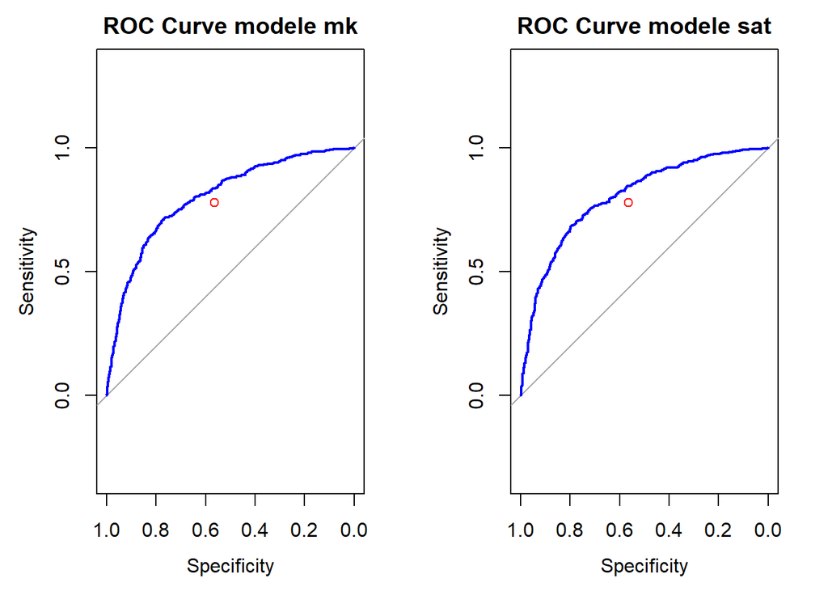

```r
par(mfrow = c(1, 2))
plot(roc_curve, col = "blue", main = "ROC Curve modele mk")
points(coords, col = "red")
plot(roc_curve_sat, col = "blue", main = "ROC Curve modele sat")
points(coords, col = "red")
```

Tres bonne performance globale du modele Le modele saturé a un meilleure AUC que le modele simple, mais la difference est peu significative

```r
#determination de l'AUC
auc_roc_curve = auc(roc_curve)
auc_roc_curve_sat = auc(roc_curve_sat)

print(paste("AUC for the regular model:", auc_roc_curve, "& AUC for the saturated model:", auc_roc_curve_sat))
```

```
## [1] "AUC for the regular model: 0.801508136985278 & AUC for the saturated model: 0.803367444587173"
```

```r
pred2 = (pred >= best_threshold)
```

```r
table(pred2, meteo_clean$pluie.demain) #matrice de confusion
```

```
##
## pred2   FALSE TRUE
##   FALSE   451  176
##   TRUE    128  425
```

74.23% de bonnes prédictions Le modele a une accuracy relativement bonne

```r
mean(pred2 == (meteo_clean$pluie.demain == "TRUE"))
```

```
## [1] 0.7423729
```

# —————————————-

# —————————————-

```r
#import de la base de données
meteo_vtest <- read.csv("C:/Users/BelhaA/OneDrive - Louis Dreyfus Company/Desktop/Master Statistiques et Big Data - 2024/Rproject/Modele Lineraire Generalisé - Robin/meteo.test.csv")
```

```r
meteo_vtest$pluie.demain = NA

predictions_finale <- ifelse(predict(g3, newdata = meteo_vtest, type = "response")> 0.5645773, TRUE, FALSE)


meteo_vtest$pluie.demain = predictions_finale

meteo_vtest$pluie.demain
```

```
##   [1] FALSE  TRUE FALSE  TRUE FALSE FALSE  TRUE  TRUE  TRUE FALSE  TRUE  TRUE
##  [13] FALSE  TRUE  TRUE FALSE  TRUE FALSE  TRUE  TRUE FALSE FALSE FALSE FALSE
##  [25] FALSE  TRUE FALSE  TRUE FALSE FALSE  TRUE  TRUE FALSE  TRUE FALSE FALSE
##  [37]  TRUE  TRUE  TRUE  TRUE FALSE FALSE FALSE FALSE FALSE FALSE FALSE  TRUE
##  [49]  TRUE  TRUE FALSE FALSE  TRUE FALSE FALSE FALSE FALSE FALSE FALSE FALSE
##  [61] FALSE FALSE  TRUE  TRUE  TRUE  TRUE  TRUE FALSE  TRUE FALSE FALSE  TRUE
##  [73] FALSE FALSE FALSE FALSE FALSE  TRUE  TRUE FALSE  TRUE  TRUE  TRUE FALSE
##  [85] FALSE  TRUE FALSE  TRUE FALSE FALSE FALSE  TRUE FALSE  TRUE  TRUE  TRUE
##  [97] FALSE  TRUE FALSE  TRUE  TRUE  TRUE FALSE  TRUE FALSE FALSE FALSE  TRUE
## [109] FALSE  TRUE FALSE  TRUE FALSE FALSE  TRUE  TRUE  TRUE  TRUE  TRUE FALSE
## [121] FALSE  TRUE FALSE  TRUE  TRUE  TRUE FALSE FALSE  TRUE  TRUE  TRUE  TRUE
## [133] FALSE FALSE FALSE  TRUE FALSE FALSE  TRUE FALSE  TRUE  TRUE FALSE  TRUE
## [145]  TRUE FALSE  TRUE FALSE  TRUE  TRUE FALSE  TRUE FALSE  TRUE FALSE FALSE
## [157] FALSE FALSE FALSE FALSE  TRUE FALSE FALSE FALSE FALSE FALSE  TRUE FALSE
## [169]  TRUE FALSE  TRUE  TRUE  TRUE  TRUE FALSE  TRUE  TRUE FALSE FALSE  TRUE
## [181] FALSE FALSE  TRUE FALSE  TRUE  TRUE FALSE  TRUE FALSE FALSE FALSE FALSE
## [193] FALSE FALSE FALSE FALSE FALSE FALSE  TRUE FALSE  TRUE FALSE  TRUE  TRUE
## [205]  TRUE  TRUE  TRUE  TRUE  TRUE  TRUE  TRUE  TRUE FALSE  TRUE  TRUE  TRUE
## [217]  TRUE  TRUE  TRUE  TRUE  TRUE FALSE FALSE  TRUE  TRUE FALSE FALSE FALSE
## [229]  TRUE FALSE  TRUE  TRUE FALSE FALSE FALSE FALSE FALSE FALSE FALSE FALSE
## [241] FALSE  TRUE  TRUE  TRUE  TRUE FALSE FALSE FALSE  TRUE FALSE  TRUE FALSE
## [253]  TRUE  TRUE FALSE FALSE  TRUE  TRUE FALSE  TRUE  TRUE  TRUE  TRUE FALSE
## [265]  TRUE  TRUE  TRUE  TRUE FALSE FALSE  TRUE  TRUE FALSE FALSE  TRUE  TRUE
## [277]  TRUE  TRUE  TRUE FALSE FALSE FALSE FALSE FALSE  TRUE  TRUE  TRUE FALSE
## [289]  TRUE  TRUE
```